# Who gets missed by an enrolment-time dropout warning?

Strong Tiger

## 1. Research question

An enrolment-time warning could help student-support staff decide whom to contact while there is still time to offer help. A low cutoff can catch more departures but also creates more follow-up work. We ask how well age, admission grade and course predict recorded dropout by the normal end of a programme. We then ask who is missed by the same warning rule and how the error patterns change at two cutoffs. The recorded outcome lets us evaluate the warnings against historical records. Whether outreach improves outcomes is a separate question.

## 2. Data and exploration

Each row in UCI dataset 697 represents a student record from one Portuguese higher education institution. The data cover enrolments from 2008/09 to 2018/19 (Realinho et al., 2022). Of the 4,424 records, 1,421 were labelled Dropout, 794 Enrolled and 2,209 Graduate. The endpoint is the normal programme duration, typically three years and four for Nursing. The source counts changes of programme or institution as dropout. We retain all three labels and code the model outcome as 1 for Dropout and 0 for Graduate or Enrolled. The zero category means no recorded dropout at that endpoint. Students in Enrolled were still studying.

We checked for empty cells, exact duplicate rows and coded categories before splitting. The downloaded table had 0 missing cells and 0 exact duplicate rows. Special codes such as unknown parental qualifications were audited separately, outside the primary model. We used numerical age and admission grade and treated course codes as categories. We excluded first- and second-semester records because they become available after the intended warning, and left out fields with uncertain recording times. Recorded gender and Displaced were used to audit errors. The source records Displaced as a yes/no field for students away from their original homes, with limited detail about how the category was assigned.

The median age in the training sample was 22 years for Dropout, 20 for Enrolled and 19 for Graduate. Median admission grades were 122.9, 124.0 and 127.1 points, respectively. Both distributions overlap across outcome groups (Figure 1).

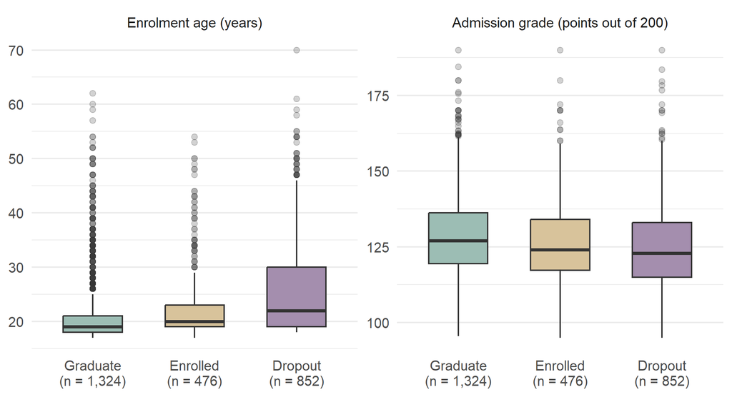

Figure 1. Enrolment age and admission grades by recorded outcome in the training data. The boxes show the middle 50% and median. Group sizes are shown below the outcome labels.

## 3. Methods

We used a fixed seed (20261105) to split the records by original outcome and recorded gender into training (2,652), validation (883) and test (889) sets. We fitted a logistic regression on training data using age and admission grade scaled in tens, plus a course factor. The model estimates a probability from a binary outcome. Its age and grade terms are linear on the log-odds scale and share the same slopes across courses.

On validation data, we selected the cutoff with the highest specificity among those that reached at least 70% sensitivity, breaking ties in favour of the higher cutoff. We chose 70% to illustrate a warning policy that prioritises finding dropouts. We then evaluated that fixed rule on the test set against the same model at 0.50 and a baseline that never warns.

After the main analysis, we ran a five-fold comparison within the original training set. Both logistic models used the same folds, stratified by original outcome and recorded gender. We compared mean fold AUC and Brier score for age and admission grade, with and without course.

Sensitivity is the fraction of recorded dropouts warned, specificity the fraction of other records left unflagged, and precision the fraction of warnings that match a dropout. Accuracy counts all matching decisions. ROC AUC measures score ranking across cutoffs. For the gender audit, we compared warning proportions (Independence), error rates at the same observed outcome (Separation), and dropout proportions within both warned and unwarned records (binary Sufficiency). Pointwise percentile intervals come from 5,000 bootstrap resamples within recorded-gender groups of the test set, with the fitted model and cutoff fixed. We used the same scores for a later exploratory comparison by Displaced.

## 4. Results

### What the fitted coefficients say

Table 1. Fitted log-odds coefficients and their exponentiated values.

| Predictor | Coefficient | Odds multiplier |
| --- | --- | --- |
| Age at enrolment, per 10 years | 0.695 | 2.004 |
| Admission grade, per 10 points | -0.170 | 0.844 |

At the same admission grade and course, a student ten years older had estimated odds of recorded dropout about twice as high. At the same age and course, ten more admission points were associated with about 16% lower odds. The coefficients describe associations conditional on the other model inputs. The probability difference depends on the starting probability. Each course coefficient compares its course with Animation and Multimedia Design (course 171), at the same age and grade.

### The warning cutoff changes the errors

The validation rule chose 0.31. On 889 test records, it caught 187 of 285 dropout records and missed 98. Lowering the cutoff from 0.50 to 0.31 caught 107 more dropout records and generated 177 more false warnings. The no-warning baseline had higher accuracy than our chosen rule and caught zero cases. ROC AUC was 0.718 (95% conditional bootstrap interval 0.682 to 0.754). That score is shared by the two cutoffs, which use the same probability ranking.

Table 2. Three decision rules applied to the same 889 test records.

| Decision | Dropouts caught | Missed | False warnings | Sensitivity | Specificity | Precision | Accuracy |
| --- | --- | --- | --- | --- | --- | --- | --- |
| Never warn | 0 | 285 | 0 | 0.0% | 100.0% | Undefined | 67.9% |
| Warn at 0.50 | 80 | 205 | 45 | 28.1% | 92.5% | 64.0% | 71.9% |
| Warn at 0.31 | 187 | 98 | 222 | 65.6% | 63.2% | 45.7% | 64.0% |

### Who is missed by the same rule?

At 0.31, the rule missed a greater share of recorded female dropouts. The female-minus-male gap was 20.3 percentage points (95% conditional bootstrap interval 9.5 to 30.7). The false-warning rate was higher for male records without dropout. Warning rates also differed, and the dropout proportions in both warning categories differed by recorded gender. The observed dropout proportions among all female and male records were 25.0% and 44.9%, which helps explain why these group comparisons answer different questions.

Table 3. Group counts, denominators and rates at the 0.31 cutoff.

| Criterion | Comparison | Female | Male |
| --- | --- | --- | --- |
| Independence | Warned out of all | 218/575 (37.9%) | 191/314 (60.8%) |
| Separation | Missed among dropouts | 64/144 (44.4%) | 34/141 (24.1%) |
| Separation | Warned among non-dropouts | 138/431 (32.0%) | 84/173 (48.6%) |
| Sufficiency | Dropout among warned | 80/218 (36.7%) | 107/191 (56.0%) |
| Sufficiency | Dropout among unwarned | 64/357 (17.9%) | 34/123 (27.6%) |

Raising the cutoff to 0.50 narrowed the female-minus-male gap to 13.2 percentage points. Yet the rule now missed 113/144 (78.5%) female dropout records and 92/141 (65.2%) male dropout records. Total misses rose from 98 to 205. Looking only at the smaller gap would hide what happened to both groups.

The exploratory Displaced comparison went the other way. Its missed-dropout gap widened from 15.7 to 21.1 percentage points. The group marked Displaced had a lower false-warning rate at both cutoffs.

Table 4. Exploratory error comparison by Displaced status at both cutoffs.

| Cutoff | Displaced | Missed among dropouts | Warned among non-dropouts |
| --- | --- | --- | --- |
| 0.31 | No | 39/146 (26.7%) | 105/236 (44.5%) |
| 0.31 | Yes | 59/139 (42.4%) | 117/368 (31.8%) |
| 0.50 | No | 90/146 (61.6%) | 35/236 (14.8%) |
| 0.50 | Yes | 115/139 (82.7%) | 10/368 (2.7%) |

For students recorded as living away from home, raising the cutoff from 0.31 to 0.50 meant 56 more missed dropouts and 107 fewer false warnings on the same test set.

### What does course add?

Table 5. Five-fold comparison within the 2,652 original training records.

| Predictors | Mean AUC | Mean Brier score |
| --- | --- | --- |
| Age and admission grade | 0.668 | 0.204 |
| Age, admission grade and course | 0.702 | 0.196 |

Adding course improved AUC and reduced squared probability error in all five folds. That supports keeping course as a predictor in these historical data. This follow-up used the training records only. The test AUC of 0.718 describes the original fitted model.

## 5. Discussion and limitations

The enrolment model detected about two-thirds of recorded dropouts at the chosen cutoff. That came with 222 false warnings and noticeably different error rates across groups. The observed gaps do not identify their causes. Course mix, underlying dropout rates and the institution’s recording practices may all matter. Keeping Enrolled in the original records preserves the distinction between continuing and graduating. Restricting evaluation to Dropout and Graduate raises AUC to 0.756 for the same primary fit, but changes the evaluation population. That result is about students with a resolved outcome, so we report it as a sensitivity check.

The model gives useful ranking information on these records, but a warning is an imperfect proxy for needing help. This distinction matters because a transfer is counted as dropout and students who remain enrolled may still benefit from support. The results concern historical data from one institution. The released data lack a cohort field for a chronological test. The bootstrap describes variation across resampled test records given the fixed fit and cutoff. It leaves out uncertainty from refitting and changes in future cohorts. The comparisons by Displaced are descriptive and would need confirmation on fresh data.

Before considering use, we would validate the frozen rule on a later cohort. We would ask staff whether they could review 409 warnings per 889 entrants, and ask students what a transfer or another recorded departure meant for them. Students without warnings would still need a route to help. A separate evaluation of outreach would be needed to learn whether it improves outcomes.

## Reproducibility and sources

The [group repository](https://github.com/Tigershengsheng/ids-project) contains the raw data and R scripts. From the project root in RStudio, use `source("R/analysis.R")` to regenerate results and then knit this report. `verify_project.R` checks the split, threshold and main results.

- Realinho et al. (2021). *Predict Students’ Dropout and Academic Success*. UCI Machine Learning Repository. [Dataset](https://doi.org/10.24432/C5MC89), accessed 5 November 2026.
- Realinho et al. (2022). *Predicting Student Dropout and Academic Success*. *Data*, 7(11), 146. [Data descriptor](https://doi.org/10.3390/data7110146).
- Introduction to Data Science (2026/27). *Cross Validation*, slides 29–33 and 38–40.

## Generative AI disclosure

Our team chose the project topic and directed the focus on threshold trade-offs and the exploratory Displaced comparison. ChatGPT assisted with code, source checks, report drafting and revision, and presentation design. The group’s presentation draft also used AI-generated illustrative images. All numerical results in this report are generated in R.